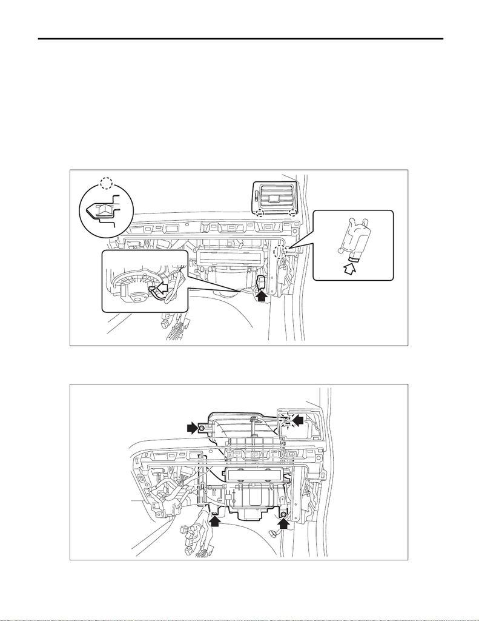

AC-35

Blower Motor Unit Assembly

HVAC SYSTEM (HEATER, VENTILATOR AND A/C)

9. Blower Motor Unit Assembly

A: REMOVAL

1) Disconnect the ground cable from battery. <Ref. to NT-5, BATTERY, NOTE, Note.>

NOTE:

For models other than STI model, disconnect the ground terminal from battery sensor.

2) Remove the glove box. <Ref. to EI-63, REMOVAL, Glove Box.>

Module (ECM).>

4) Remove the blower motor unit assembly.

(1) Release the claws, and then remove the grille assembly - ventilation RH.

(2) Disconnect the blower motor relay and each connector.

(3) Remove the bolts and nuts to remove blower motor unit assembly.

NOTE:

Remove the RH upper nut from the mounting portion of the grille assembly - ventilation RH.

AC-03548

AC-02707

[figure not shown]

AC-36

Blower Motor Unit Assembly

HVAC SYSTEM (HEATER, VENTILATOR AND A/C)

B: INSTALLATION

CAUTION:

ventilation RH is inserted correctly into the air vent duct.

1) Install the blower motor unit assembly.

Tightening torque:

7.5 N·m (0.8 kgf-m, 5.5 ft-lb)

2) Install the grille assembly - ventilation RH

trol Module (ECM).>

4) Install the glove box.

5) Connect the battery ground terminal. <Ref. to NT-5, BATTERY, NOTE, Note.>

NOTE:

For models other than STI model, connect the ground terminal to battery sensor.